# Practical Assignment 2 - Web and Text Mining

João Pires, Vanessa Silva

30 de Abril de 2017

This report follows the analysis of [IMDb](http://www.imdb.com) movies and their reviews, is the retrieval of relevant information on movies and the analysis of the reviews (and the corresponding scores) assigned by users. For this we will use our knowledge regarding web and text mining.

*Web Mining* consists of extracting information from the content of the pages, their links, and users’ browsing logs, using data mining tools. Thus, we can divide Web Mining into three variants: Web Content Mining; Web Structure Mining; And Web Usage Mining.

*Text Mining* consists of extracting useful information from a collection of documents. Involves basic pre-processing/text mining operations, such as identification/extraction of representative features, and identification of complex patterns as, e.g. relationships between previously identified concepts. Text Mining exploits techniques/methodologies from data mining, machine learning, information retrieval, and corpus-based computational linguistics, where corpus is a collection of documents.

**The Goal**

To use web and text mining to extract and study important informations in the movies and their reviews from the IMDb website.

## Necessary Packages

```r
# Install the necessary packages
install.packages("rvest")
install.packages("tm")
install.packages("wordcloud")
install.packages("SnowballC")
install.packages("qdap")
install.packages("e1071")
install.packages("earth")
install.packages("DMwR")
install.packages("performanceEstimation")
```

```r
# Load the necessary packages
library(rvest)
library(tm)
library(wordcloud)
library(qdap)
library(e1071)
library(earth)
library(DMwR)
library(performanceEstimation)
```

## Tasks

Using the information available in the IMDb site we will accomplish a series of tasks below.

### Find basic information

First we will find basic information as web page, diretor, cast, etc. of a movie based on a query string of the title.

In order to do this, we present a function (`listMovies`) that the user can call with a search string and a limit number (parameter we want to add) from the list of movies that will be returned corresponding to that string, since the string can be incomplete and therefore potentially match more than one movie in the site’s database. The list returned by the function is ordered decreasingly by the order of confidence, where we stipulate to be the rating of the films.

`listMovies` is aided by a set of other functions presented (`Searchform`, `listMoviesAll` and `webPages`), which, respectively, help to: submit the form in `imdb.com` with the search string, find the list of all movies matching the string that the site presents, and get the links from the web pages of all those movies.

```r
# Store web url
url_IMBD <- "http://www.imdb.com/"

# Submit the form on imdb.com for a movie description
Searchform <- function(session, query, type) {
  form <- html_form(session)[[1]]
  form <- set_values(form, q = query, s = type)

  return(submit_form(session, form))
}

# Returns web pages link
webPages <- function(listResults) {

  results <- listResults[[2]]

  # Get web page link
  movieLink <- (results %>% html_nodes(".result_text > a") %>% html_attr("href"))
  movieLink <- paste(url_IMBD, substring(movieLink, 2), sep='')

  return(movieLink)

}

# Returns a list of all movies matching the search string in the site
listMoviesAll <- function(query, type) {
  #Simulate a session in an html browser
  sessionMovies <- html_session(url_IMBD)

  results <- Searchform(sessionMovies, query, type)

  return(list(results %>% html_nodes(".result_text") %>% html_text(), results))
}

# Returns a list of the movies matching the search string, by decreasing order of confidence
listMovies <- function(query, maxNum) {
  type <- "tt"

  r <- listMoviesAll(query, type)

  TMlist <- r[[1]]

  movieLink <- webPages(r)

  # get rankings
  movieRanking <- lapply(movieLink, . %>% read_html() %>% html_nodes("strong span") %>% html_text())
  movieRanking <- as.array(movieRanking)

  # get data frame with movies and their ranking
  ResulList <- data.frame(as.array(TMlist),movieRanking)
  names(ResulList) <- c("Movies", "Ranking")
  ResulList$Ranking <- as.double(ResulList$Ranking)

  return(as.list((head(ResulList[order(ResulList$Ranking, decreasing=TRUE), ], maxNum))$Movies))
}
```

We can now use this function `listMovies` with the Lego Movie.

```r
Query <- "Lego"       #search string
NumMovies <- 10       #extra parameter that controls the maximum number of retrieved movies
```

```r
(ResultListMovies <- listMovies(Query, NumMovies))
```

[output not shown]

After getting the movie list we will finally get the basic information for each movie. For this we need the links of the web page of each film. Since we change the order as the list is presented and we limit the size of the list, we need to do some manipulation to get the links correctly, since the `webPages` function returns the links of all the movies in the order they are presented on the site.

```r
# Get link from web pages of n movies

FullList <- listMoviesAll(Query, "tt")
```

```
## Submitting with '<unnamed>'
```

```r
results <- FullList[2][[1]]
movieLink <- webPages(list(results %>% html_nodes(".result_text") %>% html_text(), results))

links <- matrix(nrow=NumMovies,ncol=2)
idx <- 1

for(i in 1:length(movieLink))
  for(j in 1:length(ResultListMovies))
    if (ResultListMovies[j][[1]] == FullList[1][[1]][i]){
      links[idx, 1] <- movieLink[i]
      links[idx,2] <- j
      idx <- idx+1
    }

movieLink <- matrix(ncol = NumMovies)

for(i in 1:10) {
  idx <- as.integer(links[i,2])
  movieLink[idx] <- links[i,1]
}

(movieLink <- as.character(movieLink))
```

```
##  [1] "http://www.imdb.com/title/tt3253986/?ref_=fn_tt_tt_196"
##  [2] "http://www.imdb.com/title/tt0068646/?ref_=fn_tt_tt_13"
##  [3] "http://www.imdb.com/title/tt0071562/?ref_=fn_tt_tt_22"
##  [4] "http://www.imdb.com/title/tt0060196/?ref_=fn_tt_tt_40"
##  [5] "http://www.imdb.com/title/tt4833776/?ref_=fn_tt_tt_92"
##  [6] "http://www.imdb.com/title/tt4776398/?ref_=fn_tt_tt_41"
##  [7] "http://www.imdb.com/title/tt2071508/?ref_=fn_tt_tt_45"
##  [8] "http://www.imdb.com/title/tt1577924/?ref_=fn_tt_tt_3"
##  [9] "http://www.imdb.com/title/tt5114356/?ref_=fn_tt_tt_11"
## [10] "http://www.imdb.com/title/tt5853176/?ref_=fn_tt_tt_19"
```

Having the link to the movie’s webpage and the CSS selectors we want, we can finally get the basic information for each movie. We will present the following basic information: webpage, original title, genre, rating, description, storyline, cast, date, runtime and metascore, on the form of list for each movie, each film being an element of a list as well.

We can see that some movie sites do not contain some of the requested information, obtaining the following result *character(0)*.

```r
listBasInf <- list()

for(i in 1:NumMovies) {
  l <- list()
  j <- 1

  ##web page
  l[[j]] <- list(WebPage = (movieLink[i] %>% read_html()))
  j <- j+1
  ##original title
  l[[j]] <- list(OriginalTitle = (movieLink[i] %>% read_html() %>% html_nodes(".originalTitle") %>% html_text()))
  j <- j+1
  ##genre
  l[[j]] <- list(Genre = (movieLink[i] %>% read_html() %>% html_nodes(".subtext .itemprop") %>% html_text()))
  j <- j+1
  ##rating
  l[[j]] <- list(Ratink = (movieLink[i] %>% read_html() %>% html_nodes("strong span") %>% html_text()))
  j <- j+1
  ##description
  l[[j]] <- list(Description = (movieLink[i] %>% read_html() %>% html_nodes(".summary_text") %>% html_text()))
  j <- j+1
  ##storyline
  l[[j]] <- list(Storyline = (movieLink[i] %>% read_html() %>% html_nodes("#titleStoryLine p") %>% html_text()))
  j <- j+1
  ##cast
  l[[j]] <- list(Cast = (movieLink[i] %>% read_html() %>% html_nodes("#titleCast .itemprop span") %>% html_text()))
  j <- j+1
  ##date
  l[[j]] <- list(Date = (movieLink[i] %>% read_html() %>% html_nodes(".subtext a~ .ghost+ a") %>% html_text()))
  j <- j+1
  ##runtime
  l[[j]] <- list(Runtime = (movieLink[i] %>% read_html() %>% html_nodes("#titleDetails time") %>% html_text()))
  j <- j+1
  ##metascore
  l[[j]] <- list(Metascore = movieLink[i] %>% read_html() %>% html_nodes(".score_favorable span") %>% html_text())

  listBasInf[[i]] <- list(l)
}

listBasInf[[1]]
```

```
## [[1]]
## [[1]][[1]]
## [[1]][[1]]$WebPage
## {xml_document}
## <html xmlns:og="http://ogp.me/ns#" xmlns:fb="http://www.facebook.com/2008/fbml">
## [1] <head>\n<meta http-equiv="Content-Type" content="text/html; charset= ...
## [2] <body id="styleguide-v2" class="fixed">\n<script>\n    if (typeof ue ...
##
##
## [[1]][[2]]
## [[1]][[2]]$OriginalTitle
## character(0)
##
##
## [[1]][[3]]
## [[1]][[3]]$Genre
## [1] "Animation" "Action"    "Adventure"
##
##
## [[1]][[4]]
## [[1]][[4]]$Ratink
## [1] "9.3"
##
##
## [[1]][[5]]
## [[1]][[5]]$Description
## [1] "\n                    After a century of hibernation, Link reawakens to once again save a ruined Hyrule from a great evil.\n            "
##
##
## [[1]][[6]]
## [[1]][[6]]$Storyline
## [1] "\nAfter a century of hibernation, Link reawakens to once again save a ruined Hyrule from a great evil.            "
##
##
## [[1]][[7]]
## [[1]][[7]]$Cast
##  [1] "Kengo Takanashi"    "Yu Shimamura"       "Kôji Takeda"
##  [4] "Noboru Yamaguchi"   "Mayu Isshiki"       "Rei Shimoda"
##  [7] "Hiroshi Naka"       "Shôko Tsuda"        "Hideaki Nonaka"
## [10] "Kumiko Watanabe"    "Takuya Masumoto"    "Kosuke Onishi"
## [13] "Arisa Sakuraba"     "Atsuyoshi Miyazaki" "Kosuke Takaguchi"
##
##
## [[1]][[8]]
## [[1]][[8]]$Date
## [1] "Video game released 3 March 2017\n"
##
##
## [[1]][[9]]
## [[1]][[9]]$Runtime
## character(0)
##
##
## [[1]][[10]]
## [[1]][[10]]$Metascore
## character(0)
```

### Obtain the information on all reviews from a movie

We now present a set of functions to perform the task of finding all reviews for a movie, as well as the rating reviews given by the review writer.

One can read, in the page [User Reviews Guidelines](http://www.imdb.com/help/show_leaf?commentsguidelines) the following: “The minimum length for reviews is 5 lines of text.”

With this we can see that the text field is mandatory, but the rating field is not. With that in mind, our function will return NA whenever the user did not provide any rating. The rating provided is then an integer between 1 and 10, the scale given by IMDb for ratings.

```r
# Function to return the comments
commentOfReview <- function (linkOfMovie) {
  movie <- linkOfMovie %>% read_html()

  # Number of comments
  n_reviews <- as.integer(strsplit((movie %>% html_nodes(".user-comments a"))[4] %>% html_text(), " ")[[1]][3])

  # Link of the page with all reviews
  linkOfMovie <- gsub("\\?ref_=fn_tt_tt_[0-9]*", "", linkOfMovie)
  reviews_page_link <- paste(linkOfMovie, "reviews?count=", n_reviews, "&start=0", sep = "")

  comments <- reviews_page_link %>% read_html() %>% html_nodes("#pagecontent") %>% html_nodes("div+ p") %>% html_text()

  return(comments)
}

# Function to return rating of a review
ratingOfReview <- function(linkOfMovie) {
  movie <- linkOfMovie %>% read_html()

  # Number of comments
  n_reviews <- as.integer(strsplit((movie %>% html_nodes(".user-comments a"))[4] %>% html_text(), " ")[[1]][3])

  # Link of the page with all reviews
  linkOfMovie <- gsub("\\?ref_=fn_tt_tt_[0-9]*", "", linkOfMovie)
  reviews_page_link <- paste(linkOfMovie, "reviews?count=", n_reviews, "&start=0", sep = "")

  reviews_images <- reviews_page_link %>% read_html() %>% html_nodes("#tn15content") %>% html_nodes("div img")

  ans <- NULL
  cnt <- 1
  for(i in 1:length(reviews_images)) {
    if(!is.na(reviews_images[i] %>% html_attr("class")) && reviews_images[i] %>% html_attr("class") == "avatar") {
      if(i == length(reviews_images)) {
        ans[cnt] <- NA
        cnt <- cnt + 1
      }
      else {
        if(!is.na(reviews_images[i + 1] %>% html_attr("class")) && reviews_images[i + 1] %>% html_attr("class") == "avatar") {
          ans[cnt] <- NA
          cnt <- cnt + 1
        }
      }
    }
    else {
      ans[cnt] <- as.integer(substr(reviews_images[i] %>% html_attr("alt"), 1, 1))
      cnt <- cnt + 1
    }
  }

  return(ans)
}

# Function to return the comments and stars given in review
fullReviews <- function(linkOfMovie) {
  ans <- data.frame(comment = commentOfReview(linkOfMovie), rating = ratingOfReview(linkOfMovie), stringsAsFactors = FALSE)

  return(ans)
}
```

We can try now this with the Lego Movie, as an example:

```r
# Lego movie:
lego_movie_link <- "http://www.imdb.com/title/tt1490017/"
dat <- fullReviews(lego_movie_link)
head(dat)
```

```
##                                                                                                                                                                                                                                                                                                          …
## 1 \nLike many of you, the first time I saw the trailer for The Lego Movie\n(2014) I thought to myself, "Are you kidding me?!" Yet another movie\nbased on a franchise of toys aimed towards families willing to cough up\nthe cash just to shut their kids up. Can't we for once make movies for\nkids th…
## 2                                                                                                                                                                                                                                                                                                        …
## 3                                                                                                                                                                                                                                                                                                        …
## 4                                                                                                                                                                                                                                                                                                        …
## 5                                                                                                                                                                                                                                                                                                        …
## 6                                                                                                                                                                                                                                                                                                        …
##   rating
## 1      8
## 2      1
## 3      9
## 4      1
## 5      8
## 6      9
```

### Model to predict the grade

The goal now is to build a model that can predict the grade of the review based on the text of such review.

#### Build a data set for learning

For this, we will construct a data set (`dataSet`) suitable for learning of this model(s).

First, let’s build a Corpus (a set of documents) with the reviews of the movie (we will continue with the previous example of the film “Lego”) so that we can perform the preprocessing tasks (Clean-ups).

There are many ways of importing documents into a **tm** Corpus object. In this case we will import documents whitch are stored as a vector of strings (one per text document). This is the goal of the `VectorSource()` call - to tell the function VCorpus that the Corpus is to be read from a series of reviews in a vector of strings (previously created data frame column).

```r
(corp <- VCorpus(VectorSource(dat$comment)))                #Create a corpus using the reviews
```

```
## <<VCorpus>>
## Metadata:  corpus specific: 0, document level (indexed): 0
## Content:  documents: 480
```

For the preprocessing task let’s use the `tm_map()` function of package **tm**, this function is one of the most important because it allows us to apply transformations to the texts forming a Corpus. Transformations basically consist in applying a function to each of the texts forming a Corpus, removing information that carries no information for our goal.

Let’s then remove white spaces, put everything in lowercase, remove punctuation characters and remove the numbers in the documents. Let’s also create a representation for each document using a bag of words approach. Some of the words on any text are too common to help in our goal, an example are stop words that occur on any language, which must be removed. Most words have many variants (e.g. “bring” and “bringing”), presenting the same concept and thus it makes sense to use a single descriptor for each of these concepts. So we should carry out the task of word stemming that picks the “root” of each word.

```r
#Preprocessing the corpus: Clean-ups
corp <-  tm_map(corp, stripWhitespace)                      # Strip extra whitespace
corp <-  tm_map(corp, content_transformer(tolower))         # Turn everything to lowercase
corp <-  tm_map(corp, removePunctuation)                    # Remove punctuation
corp <-  tm_map(corp, removeNumbers)                        # Remove numbers
corp1 <- tm_map(corp, removeWords, stopwords("english"))    # Remove stopwords
corp1 <- tm_map(corp1, stemDocument)                        # Stemming the words (keeping only the "root" of each word)
```

Now let’s create document term matrices using the `DocumentTermMatrix()` function. These are matrices that contain one row per document and where the columns are terms (typically words) appearing in all corpus. By default the matrix is filled with term frequencies.

```r
(dtm <- DocumentTermMatrix(corp1))
```

```
## <<DocumentTermMatrix (documents: 480, terms: 7076)>>
## Non-/sparse entries: 55339/3341141
## Sparsity           : 98%
## Maximal term length: 56
## Weighting          : term frequency (tf)
```

```r
inspect(dtm[, 10:11])
```

```
## <<DocumentTermMatrix (documents: 480, terms: 2)>>
## Non-/sparse entries: 2/958
## Sparsity           : 100%
## Maximal term length: 7
## Weighting          : term frequency (tf)
## Sample             :
##      Terms
## Docs  abolish abound
##   1         0      0
##   170       1      0
##   2         0      0
##   3         0      0
##   386       0      1
##   4         0      0
##   5         0      0
##   6         0      0
##   7         0      0
##   8         0      0
```

We can see that each document is still represented by many terms. We may carry out a further cleaning of some terms with the help of the function `removeSparseTerms()` that removes the terms that are too sparse.

```r
(dtm <- removeSparseTerms(dtm, 0.8))                        # Remove sparse terms
```

```
## <<DocumentTermMatrix (documents: 480, terms: 100)>>
## Non-/sparse entries: 15588/32412
## Sparsity           : 68%
## Maximal term length: 9
## Weighting          : term frequency (tf)
```

```r
#Data set for learning
dataSet <- cbind(data.frame(as.matrix(dtm), class = dat$rating))
head(dataSet)
```

```
##   action actual adult also anim arnett awesom bank batman best build busi
## 1      1      0     0    0    0      1      0    1      2    2     1    3
## 2      1      0     1    0    1      0      0    0      0    1     1    0
## 3      1      0     0    1    0      1      0    1      1    1     1    3
## 4      0      0     1    0    0      0      6    0      0    1     1    1
## 5      0      0     0    0    2      0      0    0      0    0     0    0
## 6      0      0     0    1    3      0      0    0      1    1     0    0
##   can cast charact children chris come construct creativ day didnt dont
## 1   1    0       1        1     0    2         1       3   3     0    1
## 2   0    1       0        0     0    1         0       0   0     0    0
## 3   2    0       1        0     1    0         2       2   1     0    0
## 4   2    0       0        0     0    0         0       1   0     1    0
## 5   1    0       0        0     0    0         0       0   0     0    0
## 6   2    1       2        0     0    2         1       2   0     1    0
##   elizabeth emmet end enjoy entertain even everyth expect feel ferrel film
```

[output cut: 48 more lines]

#### Prediction models and Conclusions

Sometimes we have some tag associated with each document of a given Corpus. When that the value of these tags may depends on the content of the documents, we have what is called a **Classification Problem**. These problems consist of trying to approximate an unknown function `Y=f(X_1,X_2,...,X_p)`, where `Y` is the target variable (in our case is the number of stars given by the reviewer), and `X_1,X_2,...,X_p` are descriptor variables (in our case properties of the reviews). The approximation of this unknown function is obtained based on examples where we know both the values of the descriptor variables (series of documents obtained of the reviews) and the values of the target variable (number of stars) - known as a **training set**.

Using the previous data set we will try a few prediction models and draw some conclusions from this comparison.

Initially we will use this data set for learning the SVM model to predict the grade based on the text. Let´s go randomly split the available data in two sets: a part for training and another (separate set) for testing. Then, we created the model with the training set and tested it on the testing set.

```r
dataSetTest <- dataSet[which(is.na(dataSet$class)), ]       # Save lines with NA's so we can predict its star in the end

dataSet <- dataSet[-which(is.na(dataSet$class)), ]          # Remove lines with NA's

#SVM model

## Splitting the data into a training and test set
sp <- sample(1: nrow(dataSet), as.integer(0.7*nrow(dataSet)))
tr <- dataSet[sp, ]
ts <- dataSet[-sp, ]

model <- svm(class ~ ., tr)             # obtain the model with the training set
preds <- predict(model, ts)             # apply it to obtain predictions for the test set
preds <- round(preds)

## Calculate the error rate of the predictions
cm <- table(preds, ts$class)            # confusion matrix
(err <- 1- sum(diag(cm))/sum(cm))
```

```
## [1] 0.96
```

Note that the values obtained by the models are in decimal values, but we want our forecast to be an integer value (the number of stars), so we will round, before we calculate the percentage of errors in our forecast, the values obtained using the `round()` function.

Now we will try the following models: SVMs (linear and radial kernel), Tree-based Models and MARS.

To compare these models in order to select the best(s) we will take advantage of the functionalities of the package `performanceEstimation`, where in the estimation task we use the mean absolute error (mae) and the mean squared error (mse) as evaluation metric and we use the cross-validation (CV) method.

```r
# Trying prediction models
exp <- performanceEstimation(
  PredTask(class ~ ., dataSet),
  c( Workflow(learner="earth"),
     Workflow(learner="rpartXse"),
    workflowVariants(learner="svm", learner.pars=list(kernel=c("linear", "radial")))
  ),
  EstimationTask(metrics=c("mae", "mse"), method=CV())
)
```

```
##
##
## ##### PERFORMANCE ESTIMATION USING  CROSS VALIDATION  #####
##
## ** PREDICTIVE TASK :: dataSet.class
##
## ++ MODEL/WORKFLOW :: earth
## Task for estimating  mae,mse  using
##  1 x 10 - Fold Cross Validation
##   Run with seed =  1234
## Iteration :**********
##
##
## ++ MODEL/WORKFLOW :: rpartXse
## Task for estimating  mae,mse  using
##  1 x 10 - Fold Cross Validation
##   Run with seed =  1234
## Iteration :**********
##
##
## ++ MODEL/WORKFLOW :: svm.v1
## Task for estimating  mae,mse  using
##  1 x 10 - Fold Cross Validation
##   Run with seed =  1234
## Iteration :**********
##
##
## ++ MODEL/WORKFLOW :: svm.v2
## Task for estimating  mae,mse  using
##  1 x 10 - Fold Cross Validation
##   Run with seed =  1234
## Iteration :**********
```

```r
# Some results
summary(exp)
```

```
##
## == Summary of a  Cross Validation Performance Estimation Experiment ==
##
## Task for estimating  mae,mse  using
##  1 x 10 - Fold Cross Validation
##   Run with seed =  1234
##
## * Predictive Tasks ::  dataSet.class
## * Workflows  ::  earth, rpartXse, svm.v1, svm.v2
##
## -> Task:  dataSet.class
##   *Workflow: earth
##               mae       mse
## avg     3.0734641 12.803412
## std     0.2189141  2.374984
## med     3.0653696 12.494449
## iqr     0.3632979  2.136452
## min     2.6833176  9.408008
## max     3.3399821 16.605105
## invalid 0.0000000  0.000000
##
##   *Workflow: rpartXse
##               mae       mse
## avg     3.0059356 10.913368
## std     0.1487365  1.157525
## med     3.0480815 11.348715
## iqr     0.2271823  1.718188
## min     2.7326829  8.699668
## max     3.1697561 12.137622
## invalid 0.0000000  0.000000
##
##   *Workflow: svm.v1
##               mae       mse
## avg     3.3750175 18.191020
## std     0.2909667  3.359181
## med     3.2777711 18.523862
## iqr     0.3969975  4.762229
## min     2.9690729 13.300654
## max     3.9057883 24.444161
## invalid 0.0000000  0.000000
##
##   *Workflow: svm.v2
##               mae       mse
## avg     2.7541220 10.991905
## std     0.2754458  1.803430
## med     2.7992798 11.421263
## iqr     0.4060335  3.393807
## min     2.3474508  8.549793
## max     3.1372182 13.007969
## invalid 0.0000000  0.000000
```

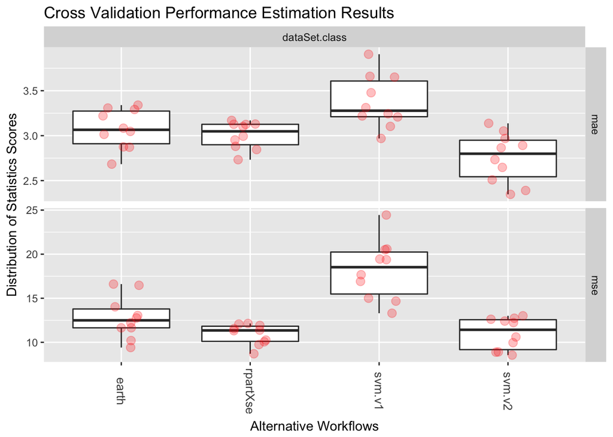

```r
plot(exp)
```

```r
topPerformers(exp)
```

```
## $dataSet.class
##     Workflow Estimate
## mae   svm.v2    2.754
## mse rpartXse   10.913
```

```r
rankWorkflows(exp,2)
```

```
## $dataSet.class
## $dataSet.class$mae
##   Workflow Estimate
## 1   svm.v2 2.754122
## 2 rpartXse 3.005936
##
## $dataSet.class$mse
##   Workflow Estimate
## 1 rpartXse 10.91337
## 2   svm.v2 10.99191
```

We can easily see that the methods with best performing are the SVM with radial kernel for the evaluation metric mean absolute error and Tree-based model for mean squared error.

Having said this, we will predict (using these two methods) the ratings of previously saved reviews (reviews which users did not assign stars).

```r
##SVM radial kernel
modelSVM2 <- svm(class ~ ., dataSet, kernel = "radial")
(predSVM2 <- predict(modelSVM2, dataSetTest))
```

```
##       15       23       41       53       55       72       74       93
## 6.693259 6.759925 6.002164 4.071501 6.334545 6.337670 3.525156 6.210768
##       99      127      150      155      167      173      184      201
## 7.051138 5.567162 5.976724 6.922553 6.214601 7.051321 9.272510 5.587900
##      206      216      218      226      228      231      243      282
## 8.411086 6.848582 6.568063 3.832361 3.491842 7.312803 4.458406 8.034749
##      286      295      296      298      300      301      312      314
## 6.356332 7.575944 5.805861 4.888932 7.080500 6.794704 6.076602 5.147908
##      315      318      320      321      322      323      345      347
## 7.159390 7.303046 4.719997 6.040921 6.270285 7.592178 3.795261 6.396067
##      349      350      351      352      353      368      377      378
## 6.286406 6.845223 8.272367 5.680879 5.355911 6.703084 6.569836 6.886871
##      385      387      390      400      405      407      409      410
## 6.355366 5.734239 8.134431 5.521432 5.427368 6.397509 8.077178 7.170140
##      415      416      428      429      440      442      465      477
## 8.260816 5.655668 6.635517 7.674571 8.464604 6.673113 6.323872 5.596717
```

```r
##Tree-based
modelTB <- rpartXse(class ~ ., dataSet)
(predTB <- predict(modelTB, dataSetTest))
```

```
##  [1] 5.612981 5.612981 5.612981 5.612981 5.612981 5.612981 5.612981
##  [8] 5.612981 5.612981 5.612981 5.612981 5.612981 5.612981 5.612981
## [15] 5.612981 5.612981 5.612981 5.612981 5.612981 5.612981 5.612981
## [22] 5.612981 5.612981 5.612981 5.612981 5.612981 5.612981 5.612981
## [29] 5.612981 5.612981 5.612981 5.612981 5.612981 5.612981 5.612981
## [36] 5.612981 5.612981 5.612981 5.612981 5.612981 5.612981 5.612981
## [43] 5.612981 5.612981 5.612981 5.612981 5.612981 5.612981 5.612981
## [50] 5.612981 5.612981 5.612981 5.612981 5.612981 5.612981 5.612981
## [57] 5.612981 5.612981 5.612981 5.612981 5.612981 5.612981 5.612981
## [64] 5.612981
```

### Summarise the reviews of a movie

The set we built for learning can and will be used in this section, but without removing the sparse items.

```r
dtm <- DocumentTermMatrix(corp)
```

We can start by doing some basic frequency analysis.

```r
# Find the most frequent words in each review with the following:
findMostFreqTerms(dtm)
```

[output not shown]

```r
# Find the words that occur more than 50 times
findFreqTerms(dtm, 50)
```

```
##   [1] "about"        "absolutely"   "action"       "actors"
##   [5] "actually"     "adult"        "adults"       "adventure"
##   [9] "after"        "again"        "ages"         "all"
##  [13] "almost"       "along"        "also"         "always"
##  [17] "amazing"      "and"          "animated"     "animation"
##  [21] "another"      "any"          "anyone"       "anything"
##  [25] "are"          "arnett"       "around"       "audience"
##  [29] "awesome"      "back"         "bad"          "banks"
##  [33] "based"        "batman"       "because"      "been"
##  [37] "before"       "being"        "best"         "better"
##  [41] "big"          "bit"          "blocks"       "both"
##  [45] "bricks"       "build"        "building"     "business"
##  [49] "but"          "called"       "cameos"       "can"
##  [53] "cant"         "cast"         "cgi"          "chance"
##  [57] "character"    "characters"   "child"        "childhood"
```

[output cut: 72 more lines]

If we analyse the words that occur more than 50 times, we can see that “arnett” is one of the words that users used in their reviews frequently. Since one of the voices in this movie that we are analysing is from actor Will Arnett, we can infer that users talk about what they think his performance was like in this specific movie. We can also see words like “interesting”, “adventure”, “creative”, which are words that are usually used in positive comments, which is in syntony with the movie’s score on IMDb (7.8/10 stars).

We can also be interested in finding correlations between words.

```r
# Words with a correlation higher than 0.3 with the word "adventure":
findAssocs(dtm, "adventure", 0.3)
```

```
## $adventure
##         adultfor             akin           allthe     anticipating
##             0.34             0.34             0.34             0.34
##       assortment         balanced        catapults  concoctionsthis
##             0.34             0.34             0.34             0.34
##         endeavor        eradicate exceptionalafter       flashbacks
##             0.34             0.34             0.34             0.34
##          geekdom    illaspersions    inconspicuous       innerchild
##             0.34             0.34             0.34             0.34
##        itluckily         lovingly        manically           oneand
##             0.34             0.34             0.34             0.34
##            oozes     outrageously      paradisethe         plastici
##             0.34             0.34             0.34             0.34
##    ragingfilmcom    resistancethe       relentless
##             0.34             0.34             0.32
```

```r
# Words with a correlation higher than 0.5 with the word "masterpiece":
findAssocs(dtm, "masterpiece", 0.5)
```

```
## $masterpiece
##        aboutso       approval         aswell    goodaverage      kidsmovie
##           0.58           0.58           0.58           0.58           0.58
##        legofan   oscarwinning       overhype pointseriously       promoted
##           0.58           0.58           0.58           0.58           0.58
##  successpraise         wakeup
##           0.58           0.58
```

We can now find wordclouds, which are a graphical represantition of the frequencies of terms in a corpus.

[figure not shown]

```r
# Simple wordcloud with the 200 most frequent words
wordcloud(corp, colors = rainbow(20), max.words = 200)
```

As we can see, this is not that interesting, since words like “the” and “and” are really frequent and are words that do not describe the movie.

We need to remove what are called **stopwords**.

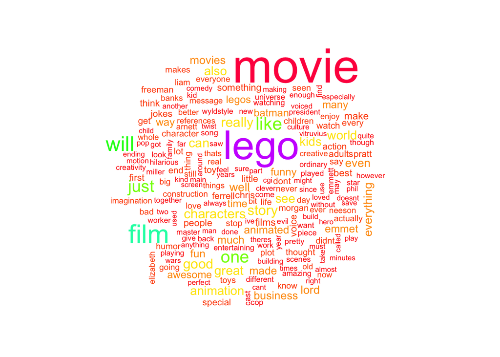

```r
corp <- tm_map(corp, removeWords, stopwords("english"))
wordcloud(corp, colors = rainbow(20), max.words = 200)
```

Yet, we can see words like animated and animation, which are words that can be used to describe the same thing. We could stem the words, keeping only the “root” of each word, but we will not do that as the results produced do not seem to be that different from what was previously done.

#### Positive and negative words in reviews

What we do now is generate two wordclouds with positive and negative words in reviews. For this, we need the package *qdap*, which requires Java to be up to date.

**NOTE**: Mac OS X users might have to run the following line in a terminal before loading library qdap:

> sudo ln -s $(/usr/libexec/java_home)/jre/lib/server/libjvm.dylib /usr/local/lib

as seen in this Stack Overflow [thread](http://stackoverflow.com/questions/30738974/rjava-load-error-in-rstudio-r-after-upgrading-to-osx-yosemite), as well as in this [source](https://github.com/snowflakedb/dplyr-snowflakedb/wiki/Configuring-R-rJava-RJDBC-on-Mac-OS-X).

```r
# Calculate the polarity from qdap dictionary
pol <- polarity(corp$content)

# Positive words:
p <- pol$all[,4]

# Negative words:
n <- pol$all[,5]

# Positive words list
positive_words <- unique(setdiff(unlist(p),"-"))
# Negative words list
negative_words <- unique(setdiff(unlist(n),"-"))
```

We can now generate the wordcloud only with positive words.

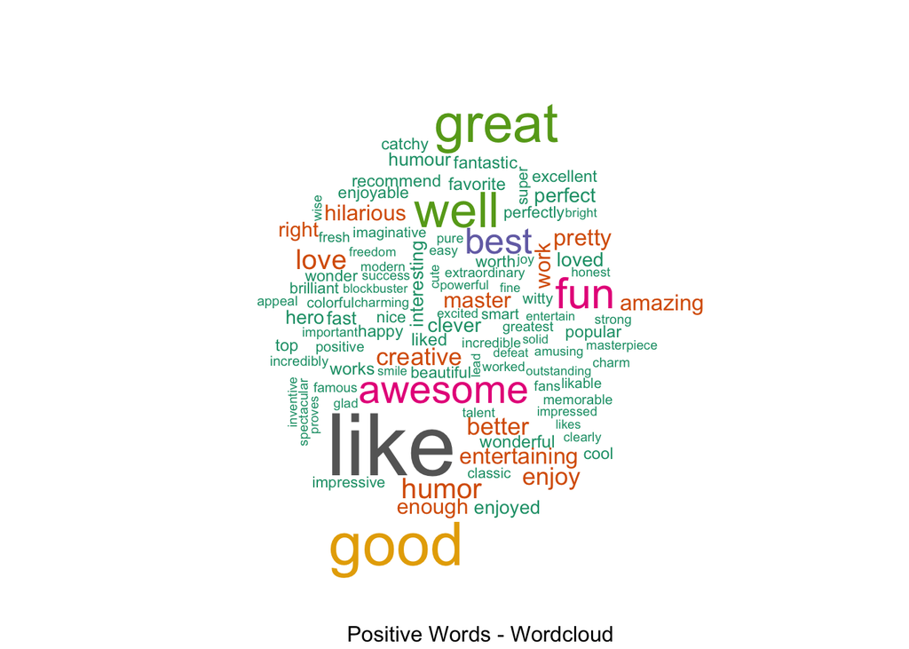

```r
pos.tdm <- dtm[,which(colnames(dtm) %in% positive_words)]
m <- as.matrix(pos.tdm)
v <- sort(colSums(m), decreasing = TRUE)
wordcloud(names(v), v, max.words=100,colors=brewer.pal(8, "Dark2"))
title(sub = "Positive Words - Wordcloud")
```

We can also generate the wordcloud only with the negative words.

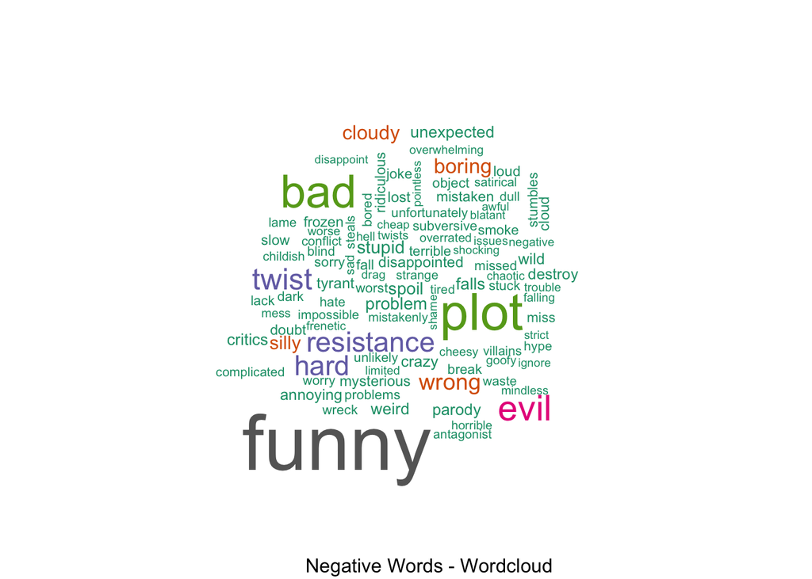

```r
neg.tdm <- dtm[,which(colnames(dtm) %in% negative_words) ]
m <- as.matrix(neg.tdm)
v <- sort(colSums(m), decreasing = TRUE)
wordcloud(names(v), v, max.words=100,colors=brewer.pal(8, "Dark2"))
title(sub = "Negative Words - Wordcloud")
```